# 医学研究のためのRによるデータ分析入門（オーム社）

# 第6章 多変量回帰モデル

CSVファイルの読みこみ

```r
new <- read.csv("new.csv")

library(rms)
dd <- datadist(new)
options(datadist = "dd")
```

## 6.1. 多変量回帰モデルの基本

```r
fit <- ols(formula = years_fu ~ treat_lab, data = new)
summary(fit)
```

```
             Effects              Response : years_fu

 Factor                        Low High Diff. Effect   S.E.    Lower 0.95
 treat_lab - Treated:Untreated 2   1    NA    -0.24402 0.32196 -0.87581
 Upper 0.95
 0.38778
```

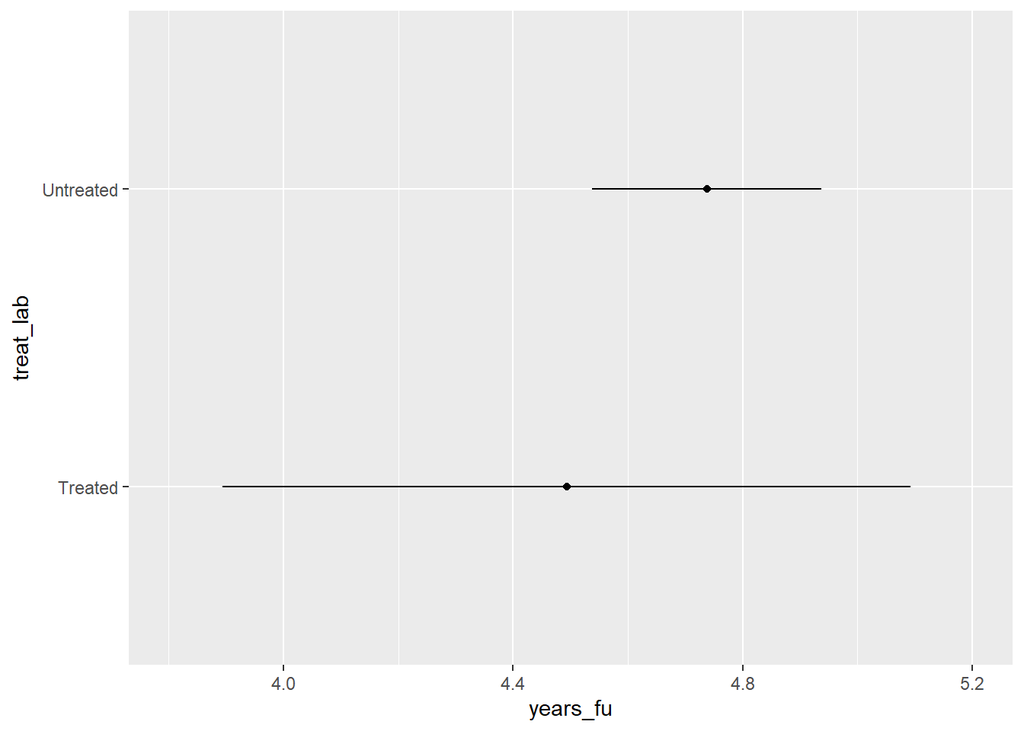

```r
pred = Predict(object = fit, treat_lab)
ggplot(data = pred)
```

```r
new$depth_lab <- ifelse(new$depth_cm>1.9, "Large", "Small")
dd <- datadist(new)
options(datadist = "dd")

fit <- ols(formula = years_fu ~ treat_lab + depth_lab, data = new)
summary(fit)
```

```
             Effects              Response : years_fu

 Factor                        Low High Diff. Effect   S.E.    Lower 0.95
 treat_lab - Treated:Untreated 2   1    NA     0.77749 0.34176  0.10682
 depth_lab - Large:Small       2   1    NA    -2.28200 0.30211 -2.87490
 Upper 0.95
  1.4482
 -1.6892
```

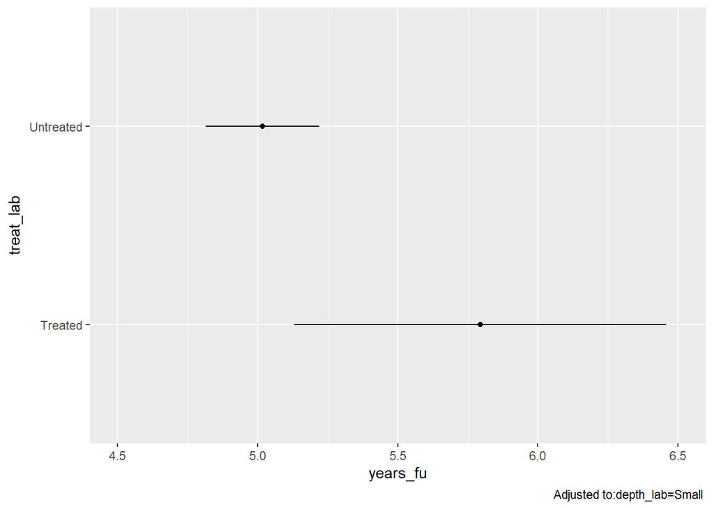

```r
pred = Predict(object = fit, treat_lab)
ggplot(data = pred)
```

## 6.2. 効果の異質性の評価

```r
fit <- ols(formula = years_fu ~ treat_y1 + sex_m1 + treat_y1 * sex_m1, data = new)
fit
```

```
Linear Regression Model

ols(formula = years_fu ~ treat_y1 + sex_m1 + treat_y1 * sex_m1,
    data = new)

                Model Likelihood    Discrimination
                      Ratio Test           Indexes
Obs    1000    LR chi2      6.01    R2       0.006
sigma3.0492    d.f.            3    R2 adj   0.003
d.f.    996    Pr(> chi2) 0.1110    g        0.142

Residuals

    Min      1Q  Median      3Q     Max
-5.0761 -2.5324 -0.5143  1.7863 10.7977

                  Coef    S.E.   t     Pr(>|t|)
Intercept          4.7369 0.1581 29.96 <0.0001
treat_y1           0.7690 0.5538  1.39 0.1653
sex_m1             0.0011 0.2064  0.01 0.9957
treat_y1 * sex_m1 -1.5122 0.6805 -2.22 0.0265
```

### 6.2.1. サブグループの効果推定

```r
contrast(fit = fit,
         a = list(treat_y1 = 1, sex_m1 = c(0,1)),
         b = list(treat_y1 = 0, sex_m1 = c(0,1)))
```

```
  sex_m1   Contrast      S.E.      Lower      Upper     t Pr(>|t|)
1      0  0.7690363 0.5538321 -0.3177754 1.85584805  1.39   0.1653
2      1 -0.7431188 0.3954424 -1.5191146 0.03287695 -1.88   0.0605

Error d.f.= 996

Confidence intervals are 0.95 individual intervals
```

### 6.2.2. 交差項を含むモデルの総括的検定

```r
anova(object = fit)
```

```
                Analysis of Variance          Response: years_fu

 Factor                                           d.f. Partial SS MS
 treat_y1  (Factor+Higher Order Factors)            2    50.75933 25.379666
  All Interactions                                  1    45.90624 45.906236
 sex_m1  (Factor+Higher Order Factors)              2    50.48339 25.241696
  All Interactions                                  1    45.90624 45.906236
 treat_y1 * sex_m1  (Factor+Higher Order Factors)   1    45.90624 45.906236
 REGRESSION                                         3    55.84231 18.614105
 ERROR                                            996  9260.13874  9.297328
 F    P
 2.73 0.0657
 4.94 0.0265
 2.71 0.0667
 4.94 0.0265
 4.94 0.0265
 2.00 0.1120
```

### 6.2.3. 効果の推定量が比であるときの異質性の評価

```r
fit <- Glm(formula = event_y1 ~ treat_y1 * sex_m1, data = new, family = poisson(link = "log"), x = T)
rfit <- robcov(fit = fit, cluster = new$id)
fit
```

```
General Linear Model

Glm(formula = event_y1 ~ treat_y1 * sex_m1, family = poisson(link = "log"),
    data = new, x = T)

                     Model Likelihood
                           Ratio Test
         Obs1000    LR chi2      0.88
Residual d.f.996    d.f.            3
         g 0.035    Pr(> chi2) 0.8312

                  Coef    S.E.   Wald Z Pr(>|Z|)
Intercept         -0.9989 0.0854 -11.69 <0.0001
treat_y1           0.1415 0.2806   0.50 0.6141
sex_m1             0.0130 0.1112   0.12 0.9068
treat_y1 * sex_m1 -0.3157 0.3625  -0.87 0.3838
```

```r
fit$coefficients
```

```
        Intercept          treat_y1            sex_m1 treat_y1 * sex_m1
      -0.99891293        0.14146270        0.01302037       -0.31574032
```

```r
exp(fit$coefficients)
```

```
        Intercept          treat_y1            sex_m1 treat_y1 * sex_m1
        0.3682796         1.1519575         1.0131055         0.7292488
```

## 6.3. 説明変数の選択

### 6.3.1. モデルの過適合のチェック

```r
fit <- ols(formula = years_fu ~ treat_lab + depth_cm + age + ps_lab, data = new, x = TRUE, y = TRUE)

set.seed(seed = 1)
validate(fit = fit, B = 200)
```

```
          index.orig training   test optimism index.corrected   n
R-square      0.1621   0.1676 0.1561   0.0116          0.1505 200
MSE           7.7317   7.6774 7.7873  -0.1099          7.8416 200
g             1.3695   1.3889 1.3498   0.0390          1.3305 200
Intercept     0.0000   0.0000 0.1238  -0.1238          0.1238 200
Slope         1.0000   1.0000 0.9739   0.0261          0.9739 200
```

### 6.3.2. 多重共線性のチェック

```r
fit <- ols(formula = years_fu ~ treat_lab + depth_cm + age + ps_lab, data = new, x = T, y = T)
vif(fit = fit)
```

```
treat_lab=Untreated            depth_cm                 age       ps_lab=Grade1
           1.209550            1.204845            1.088072            1.042680
      ps_lab=Grade2       ps_lab=Grade3
           1.054402            1.023367
```

```r
fit <- ols(formula = years_fu ~ treat_lab + depth_cm + depth_lab + age + ps_lab, data = new, x = TRUE, y = TRUE)
vif(fit = fit)
```

```
treat_lab=Untreated            depth_cm     depth_lab=Small                 age
           1.226890            2.064519            1.978583            1.090503
      ps_lab=Grade1       ps_lab=Grade2       ps_lab=Grade3
           1.043262            1.057779            1.023656
```

## 6.4. 欠測値補完

```r
# 補完なしの線形回帰モデル
fit <- ols(formula = years_fu ~ treat_lab + depth_cm, data = new)
fit
```

```
Frequencies of Missing Values Due to Each Variable
 years_fu treat_lab  depth_cm
        0         0        23

Linear Regression Model

ols(formula = years_fu ~ treat_lab + depth_cm, data = new)

                Model Likelihood    Discrimination
                      Ratio Test           Indexes
Obs     977    LR chi2    148.94    R2       0.141
sigma2.8175    d.f.            2    R2 adj   0.140
d.f.    974    Pr(> chi2) 0.0000    g        1.257

Residuals

   Min     1Q Median     3Q    Max
-5.418 -2.088 -0.575  1.584  9.704

                    Coef    S.E.   t      Pr(>|t|)
Intercept            9.8719 0.5028  19.63 <0.0001
treat_lab=Untreated -1.4601 0.3297  -4.43 <0.0001
depth_cm            -2.6280 0.2077 -12.66 <0.0001
```

```r
# 補完ありの線形回帰モデル
set.seed(1)
areg <- aregImpute(formula = years_fu ~ treat_lab + depth_cm, data = new, n.impute = 5, pr = FALSE)
fmi <- fit.mult.impute(formula = years_fu ~ treat_lab + depth_cm, data = new, fitter = ols, xtrans = areg, pr = FALSE)
fmi
```

```
Linear Regression Model

fit.mult.impute(formula = years_fu ~ treat_lab + depth_cm, fitter = ols,
    xtrans = areg, data = new, pr = FALSE)

                Model Likelihood    Discrimination
                      Ratio Test           Indexes
Obs    1000    LR chi2    164.97    R2       0.152
sigma2.8148    d.f.            2    R2 adj   0.150
d.f.    997    Pr(> chi2) 0.0000    g        1.311

Residuals

    Min      1Q  Median      3Q     Max
-5.3595 -2.0633 -0.5869  1.5583  9.7650

                    Coef    S.E.   t      Pr(>|t|)
Intercept            9.9304 0.4984  19.92 <0.0001
treat_lab=Untreated -1.4619 0.3273  -4.47 <0.0001
depth_cm            -2.7073 0.2034 -13.31 <0.0001
```

# 第7章 | 結果のアウトプット

CSVファイルの読みこみ

```r
new <- read.csv("new.csv")

library(rms)
dd <- datadist(new)
options(datadist = "dd")
```

## 7.1. 分析結果を表にまとめる

```r
# 補完ありの線形回帰モデル
set.seed(1)
areg <- aregImpute(formula = ~ years_fu + event_y1 + treat_lab + depth_cm + age + ps_lab, data = new, n.impute = 5, pr = FALSE)
fmi <- fit.mult.impute(formula = Surv(time = years_fu, event = event_y1) ~ treat_lab + depth_cm + age + ps_lab, data = new, fitter = cph, xtrans = areg, pr = FALSE)

res <- summary(fmi)
res
```

```
             Effects              Response : Surv(time = years_fu, event = event_y1)

 Factor                        Low  High Diff. Effect    S.E.     Lower 0.95
 depth_cm                       1.1  1.7  0.6   0.609000 0.078137  0.45585
  Hazard Ratio                  1.1  1.7  0.6   1.838600       NA  1.57750
 age                           44.0 65.0 21.0   0.297710 0.085309  0.13051
  Hazard Ratio                 44.0 65.0 21.0   1.346800       NA  1.13940
 treat_lab - Treated:Untreated  2.0  1.0   NA  -0.503550 0.191510 -0.87891
  Hazard Ratio                  2.0  1.0   NA   0.604380       NA  0.41524
 ps_lab - Grade1:Grade0         1.0  2.0   NA  -0.087545 0.128710 -0.33980
  Hazard Ratio                  1.0  2.0   NA   0.916180       NA  0.71191
 ps_lab - Grade2:Grade0         1.0  3.0   NA   0.023737 0.291220 -0.54704
  Hazard Ratio                  1.0  3.0   NA   1.024000       NA  0.57866
 ps_lab - Grade3:Grade0         1.0  4.0   NA   0.405640 0.587380 -0.74561
  Hazard Ratio                  1.0  4.0   NA   1.500300       NA  0.47445
 Upper 0.95
  0.76214
  2.14290
  0.46491
  1.59190
 -0.12820
  0.87968
  0.16471
  1.17910
  0.59452
  1.81220
  1.55690
  4.74410
```

```r
# 内容の抽出
res[, c(4,6,7)]
```

```
                                   Effect Lower 0.95 Upper 0.95
depth_cm                       0.60899930  0.4558537  0.7621449
 Hazard Ratio                  1.83859059  1.5775195  2.1428675
age                            0.29770866  0.1305055  0.4649119
 Hazard Ratio                  1.34676936  1.1394042  1.5918739
treat_lab - Treated:Untreated -0.50355042 -0.8789056 -0.1281953
 Hazard Ratio                  0.60438104  0.4152371  0.8796816
ps_lab - Grade1:Grade0        -0.08754536 -0.3398037  0.1647130
 Hazard Ratio                  0.91617731  0.7119100  1.1790547
ps_lab - Grade2:Grade0         0.02373679 -0.5470449  0.5945185
 Hazard Ratio                  1.02402075  0.5786573  1.8121581
ps_lab - Grade3:Grade0         0.40564384 -0.7456069  1.5568946
 Hazard Ratio                  1.50026812  0.4744463  4.7440660
```

```r
tb <- res[c(1,3,5,7,9,11),c(4,6,7)]
tb
```

```
                                   Effect Lower 0.95 Upper 0.95
depth_cm                       0.60899930  0.4558537  0.7621449
age                            0.29770866  0.1305055  0.4649119
treat_lab - Treated:Untreated -0.50355042 -0.8789056 -0.1281953
ps_lab - Grade1:Grade0        -0.08754536 -0.3398037  0.1647130
ps_lab - Grade2:Grade0         0.02373679 -0.5470449  0.5945185
ps_lab - Grade3:Grade0         0.40564384 -0.7456069  1.5568946
```

```r
# 内容の編集
tb <- as.data.frame(tb)
tb2 <- upData(object = tb,
              Effect = exp(Effect),
              `Lower 0.95` = exp(`Lower 0.95`),
              `Upper 0.95` = exp(`Upper 0.95`))
```

```
Input object size:   1624 bytes;     3 variables     6 observations
Modified variable   Effect
Modified variable   Lower 0.95
Modified variable   Upper 0.95
New object size:    1624 bytes; 3 variables 6 observations
```

```r
tb2
```

```
                                 Effect Lower 0.95 Upper 0.95
depth_cm                      1.8385906  1.5775195  2.1428675
age                           1.3467694  1.1394042  1.5918739
treat_lab - Treated:Untreated 0.6043810  0.4152371  0.8796816
ps_lab - Grade1:Grade0        0.9161773  0.7119100  1.1790547
ps_lab - Grade2:Grade0        1.0240207  0.5786573  1.8121581
ps_lab - Grade3:Grade0        1.5002681  0.4744463  4.7440660
```

```r
# 行列名の編集
rownames(x = tb2) <- c("Depth(cm)", "Age(y)", "Treated/Untreated", "PS (1/0)", "PS (2/0)", "PS (3/0)")
tb2
```

```
                     Effect Lower 0.95 Upper 0.95
Depth(cm)         1.8385906  1.5775195  2.1428675
Age(y)            1.3467694  1.1394042  1.5918739
Treated/Untreated 0.6043810  0.4152371  0.8796816
PS (1/0)          0.9161773  0.7119100  1.1790547
PS (2/0)          1.0240207  0.5786573  1.8121581
PS (3/0)          1.5002681  0.4744463  4.7440660
```

```r
colnames(x = tb2) <- c("Hazard Ratio", "95% CI Lower", "95% CI Upper")
tb2
```

```
                  Hazard Ratio 95% CI Lower 95% CI Upper
Depth(cm)            1.8385906    1.5775195    2.1428675
Age(y)               1.3467694    1.1394042    1.5918739
Treated/Untreated    0.6043810    0.4152371    0.8796816
PS (1/0)             0.9161773    0.7119100    1.1790547
PS (2/0)             1.0240207    0.5786573    1.8121581
PS (3/0)             1.5002681    0.4744463    4.7440660
```

```r
round(x = tb2, digits = 2)
```

```
                  Hazard Ratio 95% CI Lower 95% CI Upper
Depth(cm)                 1.84         1.58         2.14
Age(y)                    1.35         1.14         1.59
Treated/Untreated         0.60         0.42         0.88
PS (1/0)                  0.92         0.71         1.18
PS (2/0)                  1.02         0.58         1.81
PS (3/0)                  1.50         0.47         4.74
```

```r
# knitrによるhtml表記
#install.packages("kableExtra")
library(kableExtra)
kable(x = tb2, format = "html", digits = 2) %>%
  add_header_above(c(" " = 1, "Multivariable Cox proportional-hazard regression analysis" = 3)) %>%
  add_footnote(label = c("Hazard Ratios per IQR were presented for continuous variables.",
                         "Missing values were imputed using a multiple impuatation approach.")) %>%
  kable_styling(full_width = FALSE)
```

|  | Multivariable Cox proportional-hazard regression analysis Hazard Ratio | Multivariable Cox proportional-hazard regression analysis 95% CI Lower | Multivariable Cox proportional-hazard regression analysis 95% CI Upper |
| --- | --- | --- | --- |
| Depth(cm) | 1.84 | 1.58 | 2.14 |
| Age(y) | 1.35 | 1.14 | 1.59 |
| Treated/Untreated | 0.60 | 0.42 | 0.88 |
| PS (1/0) | 0.92 | 0.71 | 1.18 |
| PS (2/0) | 1.02 | 0.58 | 1.81 |
| PS (3/0) | 1.50 | 0.47 | 4.74 |

<sup>a</sup> Hazard Ratios per IQR were presented for continuous variables.  
<sup>b</sup> Missing values were imputed using a multiple impuatation approach.

```r
# 表の保存
write.csv(x = tb2, file = "tb_regression.csv")
```

## 分析結果を図にまとめる

### 7.2.1. ggplotの基本とヒストグラム

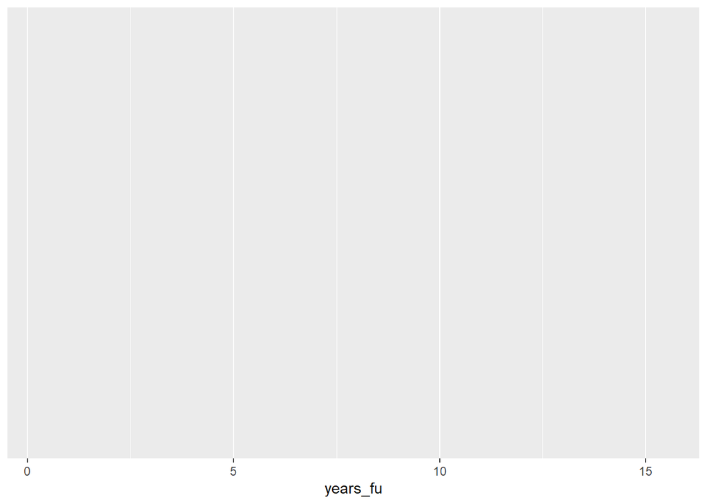

```r
#install.packages("ggplot2")
library(ggplot2)

# マッピング領域の指定
ggplot(data = new, mapping = aes(x = years_fu))
```

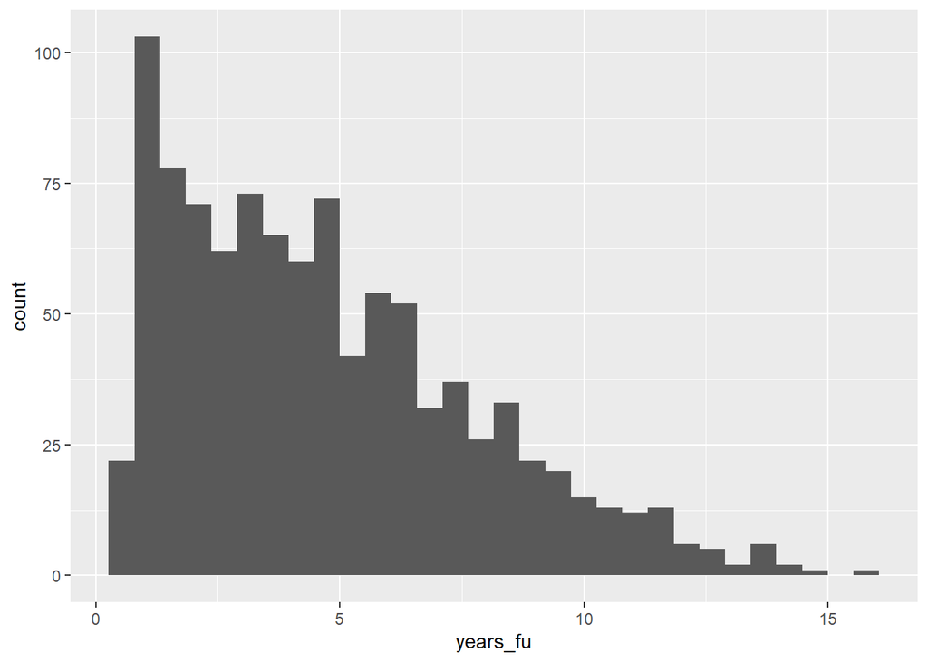

```r
# グラフ
ggplot(data = new, mapping = aes(x = years_fu)) +
  geom_histogram()
```

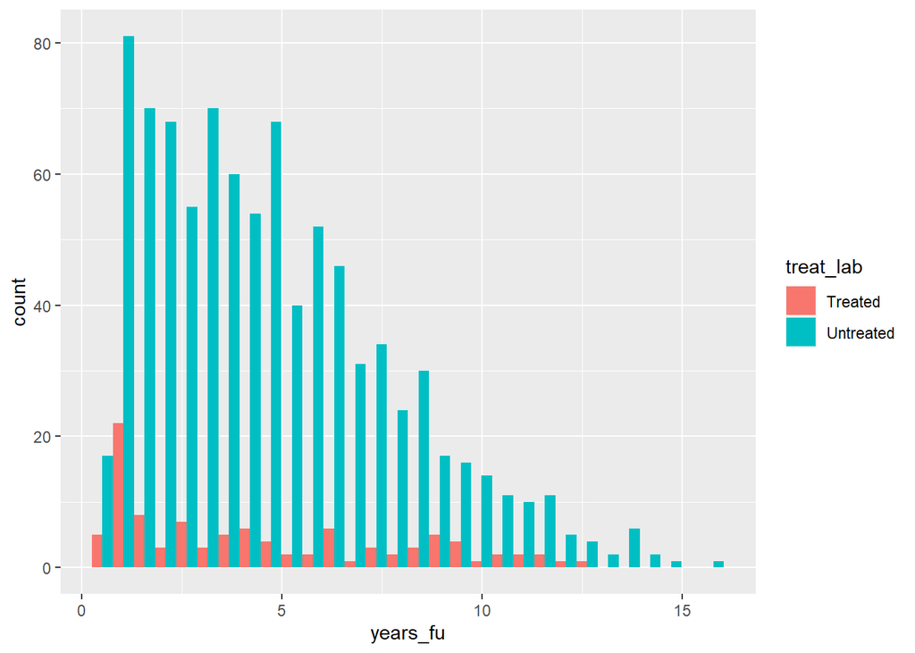

```r
# geometric objectの追加
ggplot(data = new, mapping = aes(x = years_fu)) +
  geom_histogram(mapping = aes(fill = treat_lab), # 要素間で指定値を変更する場合
                 position = "dodge")
```

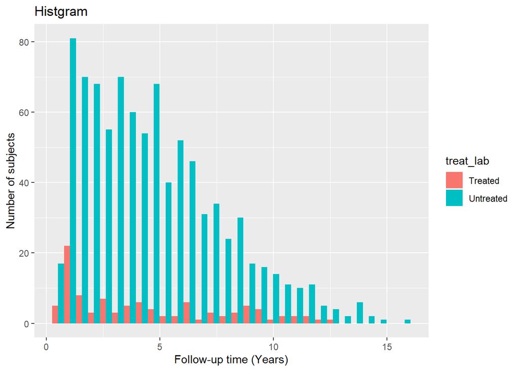

```r
# タイトル・軸ラベルの追加
ggplot(data = new, mapping = aes(x = years_fu)) +
  geom_histogram(mapping = aes(fill = treat_lab), # 要素間で指定値を変更する場合
                 position = "dodge")　+
  labs(title = "Histgram", x = "Follow-up time (Years)", y = "Number of subjects")
```

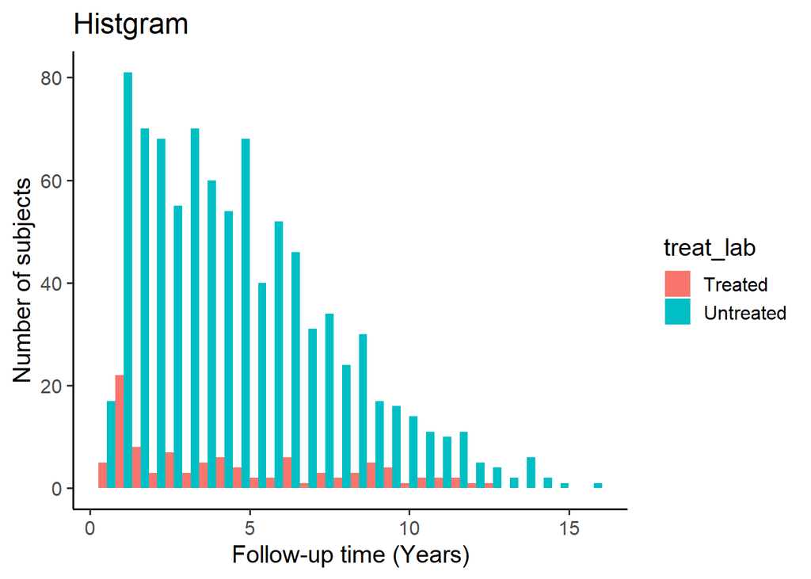

```r
# プロット全体のプリセットテーマの指定
ggplot(data = new, mapping = aes(x = years_fu)) +
  geom_histogram(mapping = aes(fill = treat_lab), # 要素間で指定値を変更する場合
                 position = "dodge")　+
  labs(title = "Histgram", x = "Follow-up time (Years)", y = "Number of subjects") +
  theme_classic(base_size = 15)
```

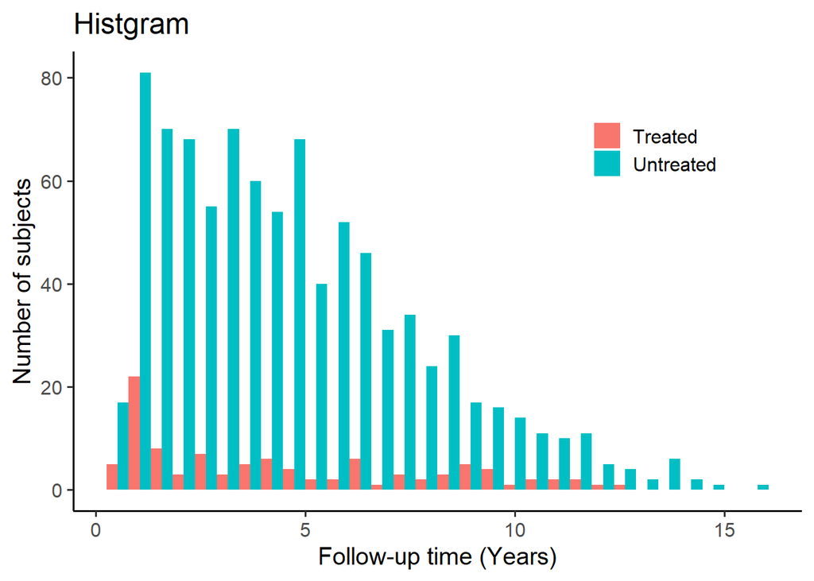

```r
# レジェンドの調整
p_hist <- ggplot(data = new, mapping = aes(x = years_fu)) +
  geom_histogram(mapping = aes(fill = treat_lab), # 要素間で指定値を変更する場合
                 position = "dodge")　+
  labs(title = "Histgram", x = "Follow-up time (Years)", y = "Number of subjects") +
  theme_classic(base_size = 15) +
  theme(legend.title = element_blank(),
        legend.position = c(0.9, 0.9),
        legend.justification = c("right","top"))
p_hist
```

```r
# 図の保存
ggsave(plot = p_hist,
       filename = "figure_hist.pdf",
       device = pdf,
       dpi = 600,
       width = 10, height = 10, units = "cm")
```

### 7.2.2. scale関数による図の調整

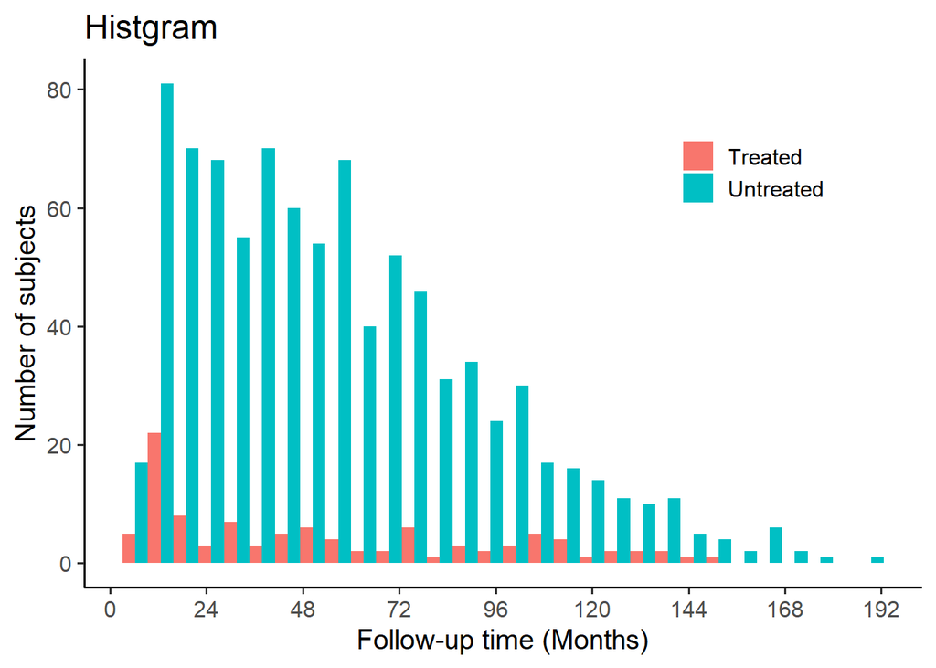

```r
xbrk <- seq(from = 0, to = 16, by = 2)
xlab <- seq(from = 0, to = 16, by = 2)*12
p_hist +
  scale_x_continuous(breaks = xbrk, labels = xlab) +
  labs(x = "Follow-up time (Months)")
```

### 7.2.3. facet関数による図の分割

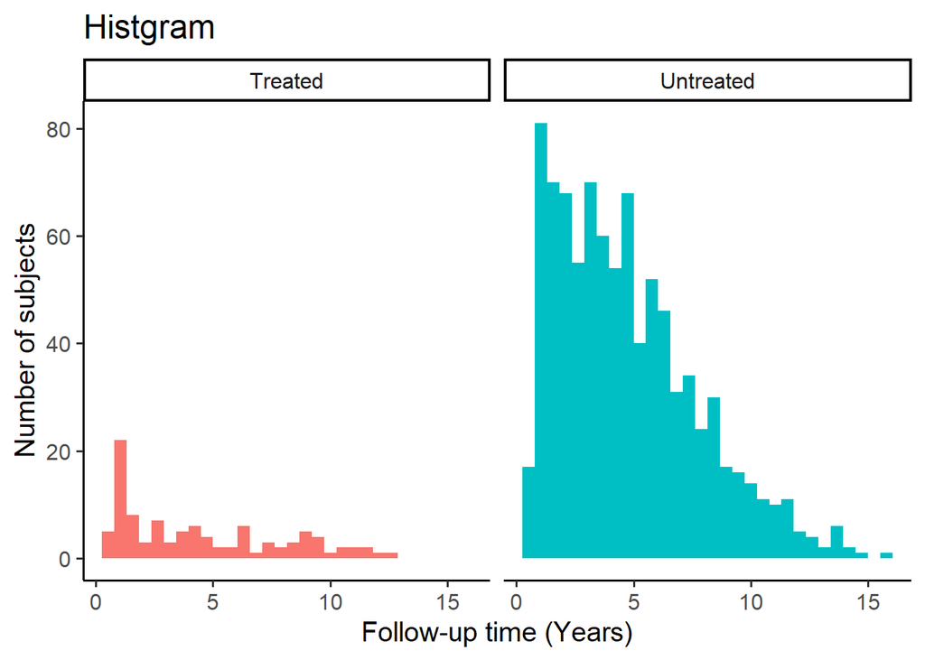

```r
p_hist +
  facet_wrap(facets = "treat_lab", nrow = 1, ncol = 2) +
  theme(legend.position = "non")
```

### 7.2.4. 箱ひげ図の作成

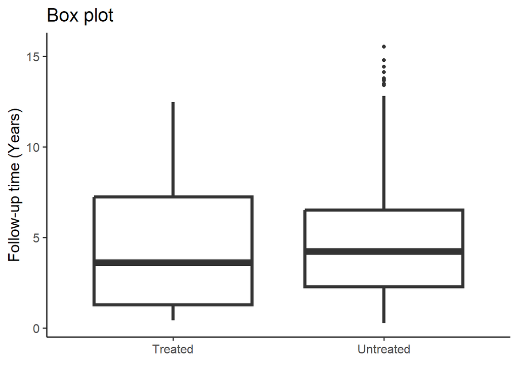

```r
p_box <- ggplot(data = new, mapping = aes(y = years_fu, x = treat_lab)) +
  geom_boxplot(size = 1.5, outlier.size = 1.5) +
  labs(title = "Box plot", x = element_blank(), y = "Follow-up time (Years)") +
  theme_classic(base_size = 15)
p_box
```

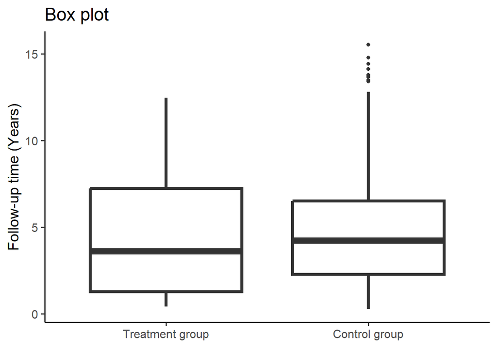

```r
xbrk <- c("Treated", "Untreated")
xlab <- c("Treatment group", "Control group")
p_box +
  scale_x_discrete(breaks = xbrk, labels = xlab)
```

### 7.2.5. 複数の図を統合する

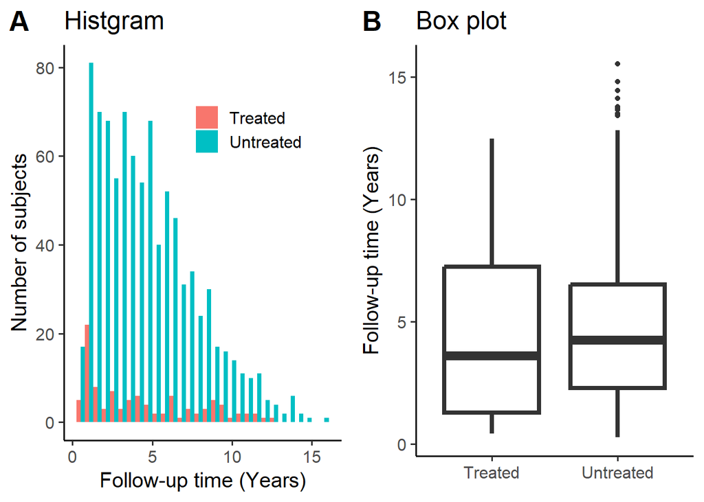

```r
#install.packages("cowplot")
library(cowplot)
p_dist <- plot_grid(plotlist = list(p_hist, p_box),
                    nrow = 1, ncol = 2,
                    labels = c("A", "B"),
                    label_size = 20)
p_dist
```

```r
# 図の保存
ggsave(plot = p_dist,
       filename = "figure_dist.pdf",
       device = pdf,
       dpi = 600,
       width = 20, height = 10, units = "cm")
```

### 7.2.6. カプランマイヤー図

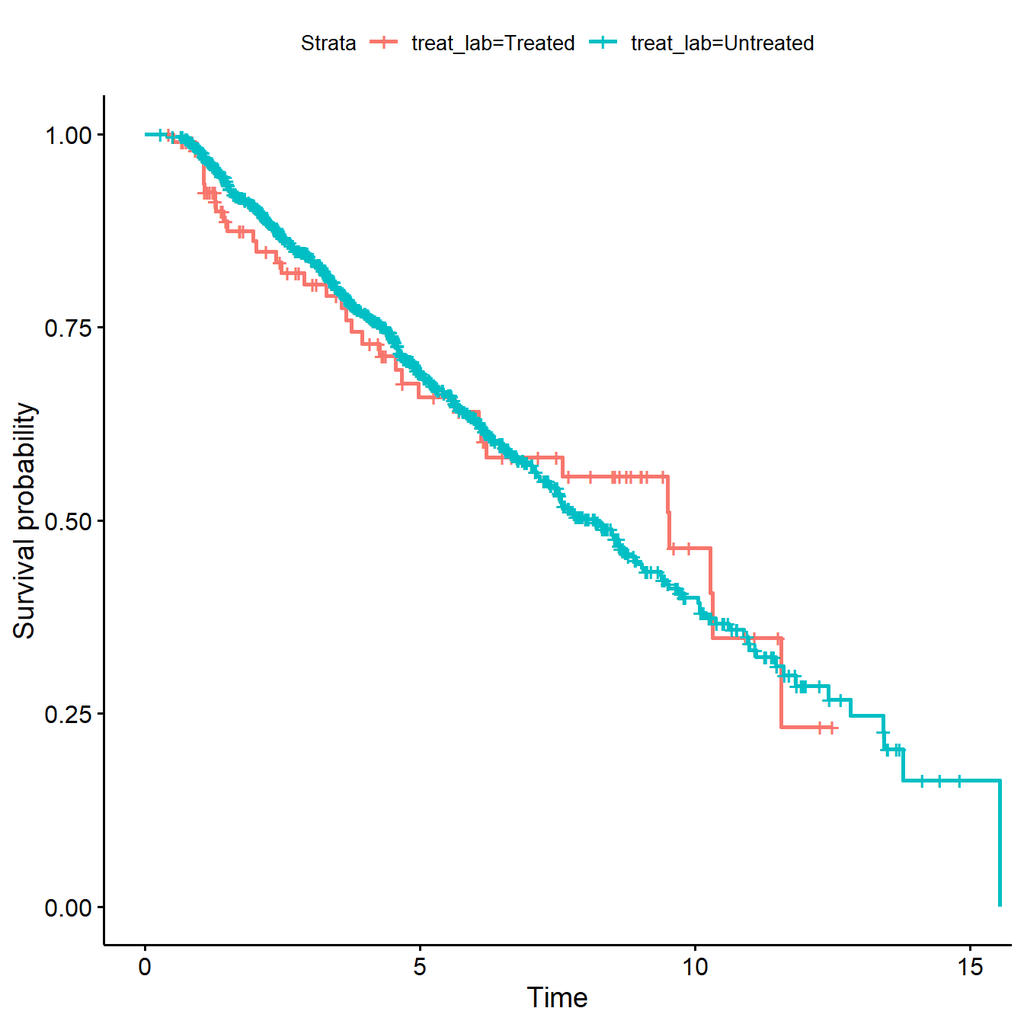

```r
# install.packages("survival")
# install.packages("survminer")
library(survival)
library(survminer)

fit = survfit(formula = Surv(time = years_fu, event = event_y1) ~ treat_lab, data = new)
ggsurvplot(fit = fit, data = new)
```

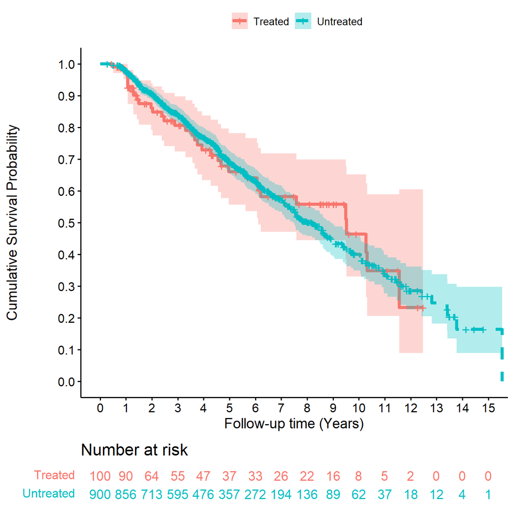

```r
p_km <- ggsurvplot(fit = fit,  # survfit()関数で推定したオブジェクト
                data = new,      # データフレーム
                censor = TRUE,  # 対象者の打ち切りを示す+マークの表示有無
                conf.int = TRUE, # 95%信頼区間の表示有無
                # リスクテーブルの付記
                risk.table = TRUE,         # リスクテーブルの有無
                risk.table.col = "strata", # 群別した場合の色分け．"black"で黒に指定可．
                risk.table.height = 0.15,  # リスクテーブルの配置の高さ．
                tables.theme = theme_cleantable(), # リスクテーブルのテーマ
                # 見栄えの調整
                size = 1.5,                                   # ラインの太さ
                linetype = c("solid", "dashed"),              # ラインの種類
                xlab = "Follow-up time (Years)",                     # X軸ラベル
                ylab = "Cumulative Survival Probability",     # Y軸ラベル
                break.x.by = 1,    # X軸の目盛を"1"刻みで表示
                break.y.by = 0.1,  # Y軸の目盛を"0.1"刻みで表示
                legend.title = "",                  # 凡例タイトル
                legend.labs = c("Treated", "Untreated"))  # 凡例ラベル
p_km
```

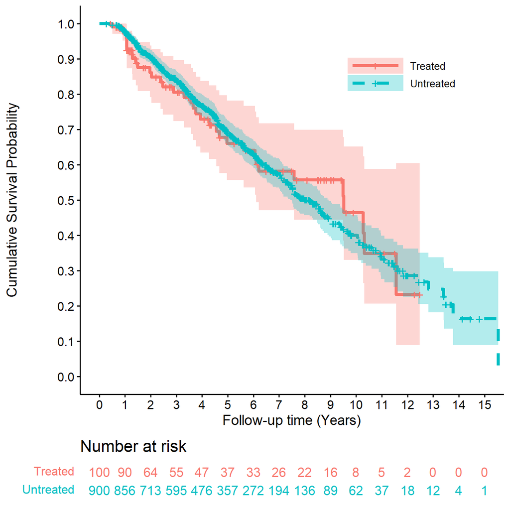

```r
# plot成分の調整
plt <- p_km$plot
p_km$plot <- plt +
  theme(legend.title = element_blank(),
        legend.position = c(0.9, 0.9),
        legend.justification = c("right","top"),
        legend.key.width = unit(2, "cm"))
p_km
```

```r
# kmの保存
pdf(file = "figure_km.pdf", width = 10, height = 10)
print(x = p_km, newpage = FALSE)
dev.off()
```

### 7.2.7. 回帰モデルの結果の図示化する

```r
set.seed(1)
areg <- aregImpute(formula = ~ years_fu + event_y1 + treat_lab + depth_cm + age + ps_lab, data = new, n.impute = 5, pr = FALSE)
fmi <- fit.mult.impute(formula = Surv(time = years_fu, event = event_y1) ~ treat_lab + depth_cm + age + ps_lab, data = new, fitter = cph, xtrans = areg, pr = FALSE)
```

離散変数に関する作図

```r
pred <- Predict(object = fmi, treat_lab)
df <- as.data.frame(pred)
head(df)
```

```
  treat_lab depth_cm age ps_lab        yhat       lower      upper
1   Treated      1.4  55 Grade0 -0.45344851 -0.79861701 -0.1082800
2 Untreated      1.4  55 Grade0  0.05010191 -0.02659065  0.1267945
```

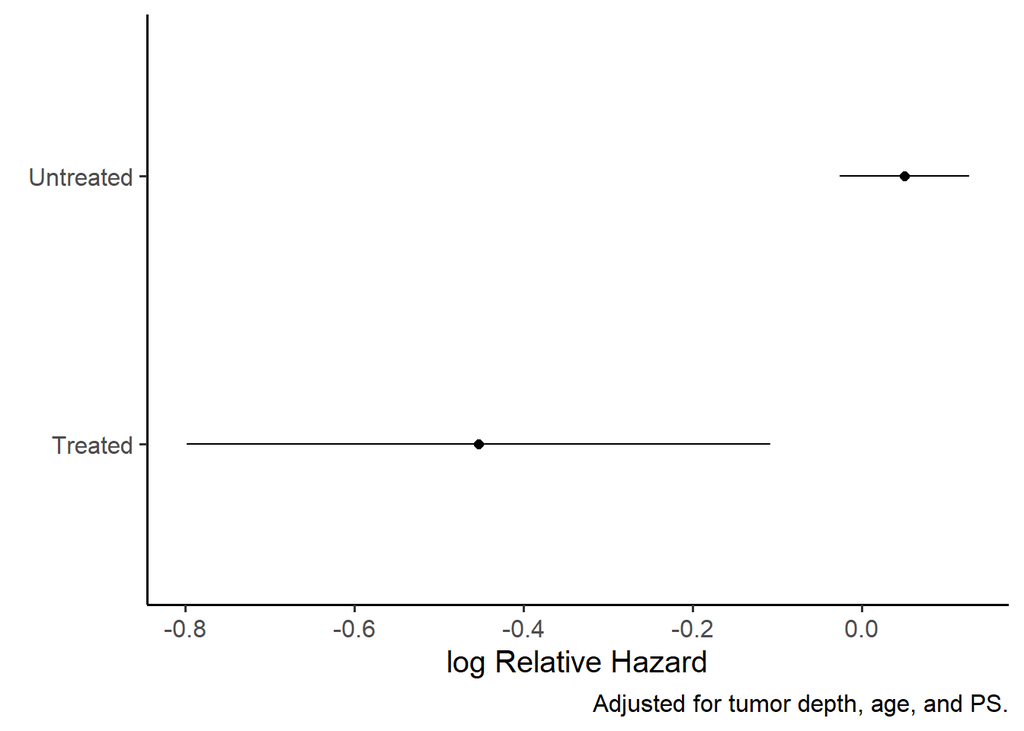

```r
fig_trt <- ggplot(data = df, mapping = aes(y = treat_lab, x = yhat)) +
  geom_point(size = 2) +
  geom_errorbar(mapping = aes(xmin = lower, xmax = upper), width = 0) +
  labs(y = element_blank(), x = "log Relative Hazard",
       caption = "Adjusted for tumor depth, age, and PS.") +
  theme_classic(base_size = 15)
fig_trt
```

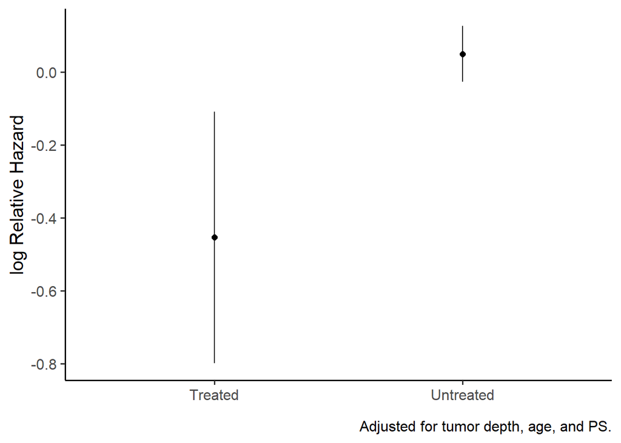

```r
fig_trt + coord_flip()
```

連続変数に関する作図

```r
pred <- Predict(object = fmi, depth_cm)
df <- as.data.frame(pred)
head(df)
```

```
  treat_lab  depth_cm age ps_lab       yhat      lower      upper
1 Untreated 0.6000000  55 Grade0 -0.7618972 -0.9775286 -0.5462657
2 Untreated 0.6110553  55 Grade0 -0.7506761 -0.9636724 -0.5376797
3 Untreated 0.6221106  55 Grade0 -0.7394550 -0.9498210 -0.5290889
4 Untreated 0.6331658  55 Grade0 -0.7282339 -0.9359747 -0.5204931
5 Untreated 0.6442211  55 Grade0 -0.7170128 -0.9221335 -0.5118921
6 Untreated 0.6552764  55 Grade0 -0.7057917 -0.9082978 -0.5032856
```

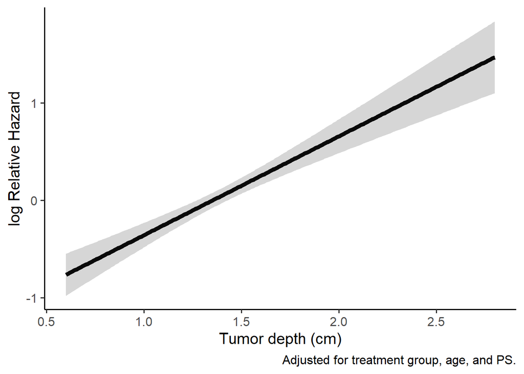

```r
ggplot(data = df, mapping = aes(y = yhat, x = depth_cm)) +
  geom_line(size = 2) +
  geom_ribbon(mapping = aes(ymin = lower, ymax = upper), alpha = 0.2) +
  labs(y = "log Relative Hazard", x = "Tumor depth (cm)",
       caption = "Adjusted for treatment group, age, and PS.") +
  theme_classic(base_size = 15)
```

交差項を含む場合の作図

```r
set.seed(1)
areg <- aregImpute(formula = ~ years_fu + event_y1 + treat_lab + depth_cm + age + ps_lab, data = new, n.impute = 5, pr = FALSE)
fmi <- fit.mult.impute(formula = Surv(time = years_fu, event = event_y1) ~ treat_lab * depth_cm + age + ps_lab, data = new, fitter = cph, xtrans = areg, pr = FALSE)

pred <- Predict(object = fmi, depth_cm, treat_lab)
df <- as.data.frame(pred)
head(df)
```

```
  treat_lab  depth_cm age ps_lab       yhat      lower      upper
1   Treated 0.6000000  55 Grade0 -1.7916528 -2.7631116 -0.8201939
2 Untreated 0.6000000  55 Grade0 -0.7171363 -0.9438772 -0.4903954
3   Treated 0.6110553  55 Grade0 -1.7761804 -2.7408384 -0.8115225
4 Untreated 0.6110553  55 Grade0 -0.7065496 -0.9304542 -0.4826450
5   Treated 0.6221106  55 Grade0 -1.7607081 -2.7185711 -0.8028451
6 Untreated 0.6221106  55 Grade0 -0.6959629 -0.9170360 -0.4748898
```

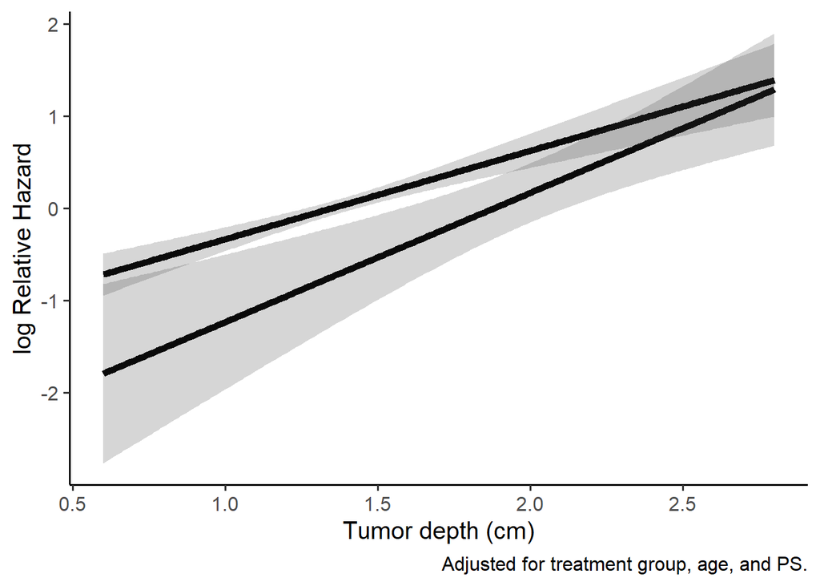

```r
# group分け
ggplot(data = df, mapping = aes(y = yhat, x = depth_cm, group = treat_lab)) +
  geom_line(size = 2) +
  geom_ribbon(mapping = aes(ymin = lower, ymax = upper), alpha = 0.2) +
  labs(y = "log Relative Hazard", x = "Tumor depth (cm)",
       caption = "Adjusted for treatment group, age, and PS.") +
  theme_classic(base_size = 15)
```

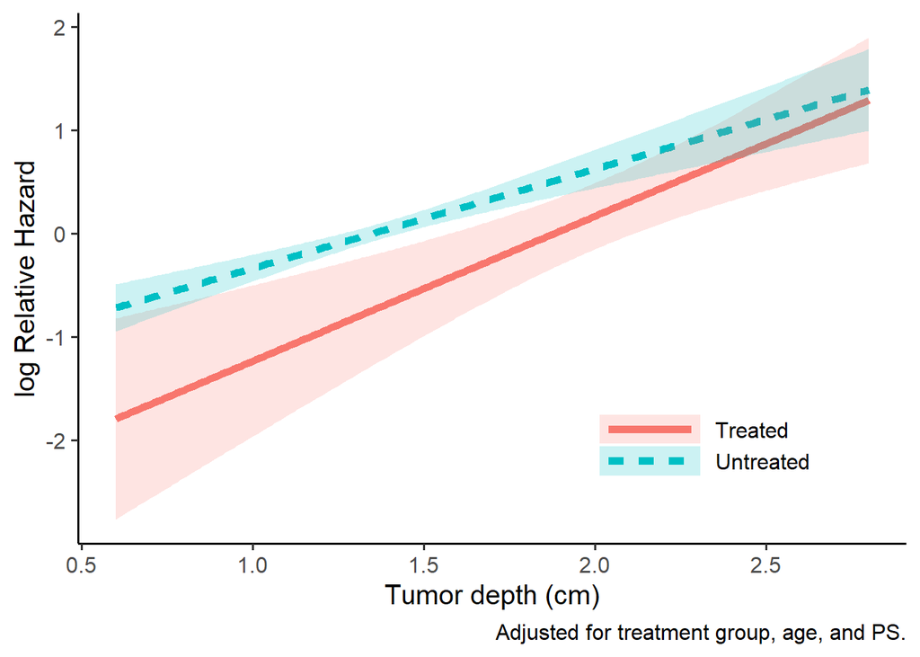

```r
# groupごとのgeom関数の設定
p_reg <- ggplot(data = df, mapping = aes(y = yhat, x = depth_cm, group = treat_lab)) +
  geom_line(mapping = aes(linetype = treat_lab, color = treat_lab), size = 2) +
  geom_ribbon(mapping = aes(ymin = lower, ymax = upper, fill = treat_lab), alpha = 0.2) +
  labs(y = "log Relative Hazard", x = "Tumor depth (cm)",
       caption = "Adjusted for treatment group, age, and PS.") +
  theme_classic(base_size = 15) +
  theme(legend.title = element_blank(), legend.position = c(0.9, 0.1), legend.justification = c("right", "bottom"), legend.key.width = unit(2,"cm"))
p_reg
```

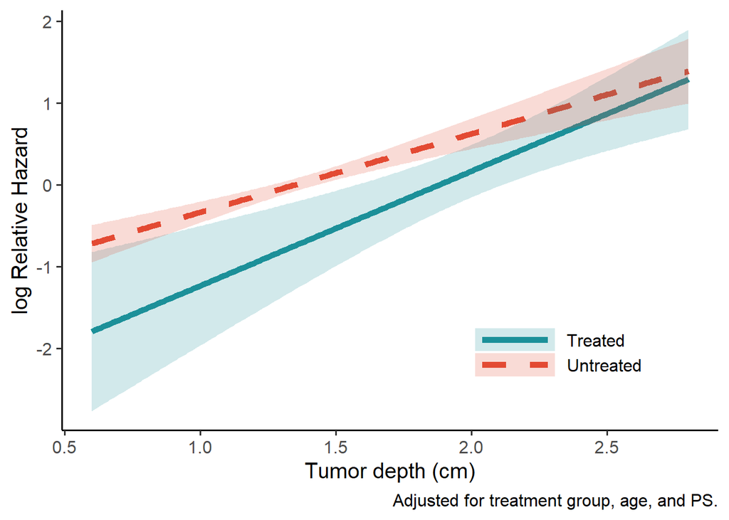

```r
# scaleによる体裁の調整
p_reg +
  scale_linetype_manual(values = c("solid", "dashed")) +
  scale_color_manual(values = c("#1c9099", "#e34a33")) +
  scale_fill_manual(values = c("#1c9099", "#e34a33"))
```

## 7.3. R Markdownで解析レポートを作成する

report.Rmd を参照．

# 第8章 | コラム

以下#を除いて利用する．

## 8.1. Rとパッケージのバージョン更新

手順１．古いRでインストール済みのパッケージをPCに一時的に保存する

```r
# install.packages("pacman")
# mypks <- pacman::p_lib()
# saveRDS(mypks, "~/mypks.rds")
```

手順２．CRANから新しいバージョンのRをインストールする

手順３．Rstudioで新しいバージョンのRを選択する

手順4．手順１で保存したパッケージを再インストールしてアップデート

```r
# mypks <- readRDS("~/mypks.rds")
# install.packages(mypks, ask = FALSE)
# update.packages(ask = FALSE)
```